# Accessiblity of National Trust Houses in England

Joseph Lewis

22 June 2018

# Why?

Founded on the simple and enduring idea that people need historic, beautiful and natural places (National Trust, 2014), National England is a conversation organisation, who preserve the nation’s heritage and open spaces for everyone to enjoy. Looking after over 500 historic houses, castles, and ancient monuments garden, the National Trust saw more than 20 million visits (National Trust, 2014).

According to the National Trust. historic buildings offer a connection to history, as well as a different perspective on the world around us (National Trust, 2014). Therefore,I wanted to explore whether there were any areas of England that were less accessible to a National Trust house.

# Background and Methodology

As defined by Guers and van Wee (2004, p.128), accessibility is the “extent to which land-use and transport systems enable individuals to reach activities or destinations”.

Although there are multiple methods for assessing accessibility (see Guers and van Eck, 2001; Talen, 2003 for a methodological review), this study utilises the Cumulative opportunity measure (e.g., handy and Niemeiere, 1997; Vickerman, 1974). Simply, the cumulative opportunity approach sums the number of essential destinations reachable within a certain time by automobiles (Golub and Martens, 2014).

In this case, the origin points will be the National trust houses, each with a drive time of 60 minutes. The essential destinations will be the location of output area centroids, with the values summed being the total population within the output areas that can be reached within the time.

By doing this, this study aims to identify spatial gaps. In other words, where there are output area centroids (and therefore populations) that are further than 60 minutes drive time from any National Trust house.

# Datasets

Due to the location of National Trust houses not being publically available within a dataset, this study utilises [Overpass Turbo](https://overpass-turbo.eu/), a web-based data filtering tool for Open Street Map to extract all buildings that have a value of “National Trust” within the “operator” key. 205 Buildings were extracted, providing 82% of the buildings that the National Trust look after (249).

The English Census Output Areas, 2011 were downloaded from [UK Data Service](https://borders.ukdataservice.ac.uk/easy_download_data.html?data=England_oa_2011) whilst the 2011 Census Population Density data (QS102EW) was downloaded from [nomis](https://www.nomisweb.co.uk/census/2011/bulk/r2_2)

# Data Preparation

```r
library(raster)
library(sp)
library(osrm)
library(maptools)
library(ggplot2)
library(viridis)
library(rgeos)
library(rgdal)
```

```r
nt_houses <- readOGR(dsn = getwd(), layer="Nat_Trust_Houses")
oa <- readOGR(dsn = getwd(), layer="england_oa_2011")
pop <- read.csv(file = "QS102EWDATA.csv", stringsAsFactors=FALSE)
```

```r
oa$group <- 1

eng_outline <- unionSpatialPolygons(oa, IDs = oa$group)

eng_outline <- spTransform(eng_outline, "+proj=longlat +ellps=WGS84 +datum=WGS84 +no_defs")
```

# Isochrone Generation

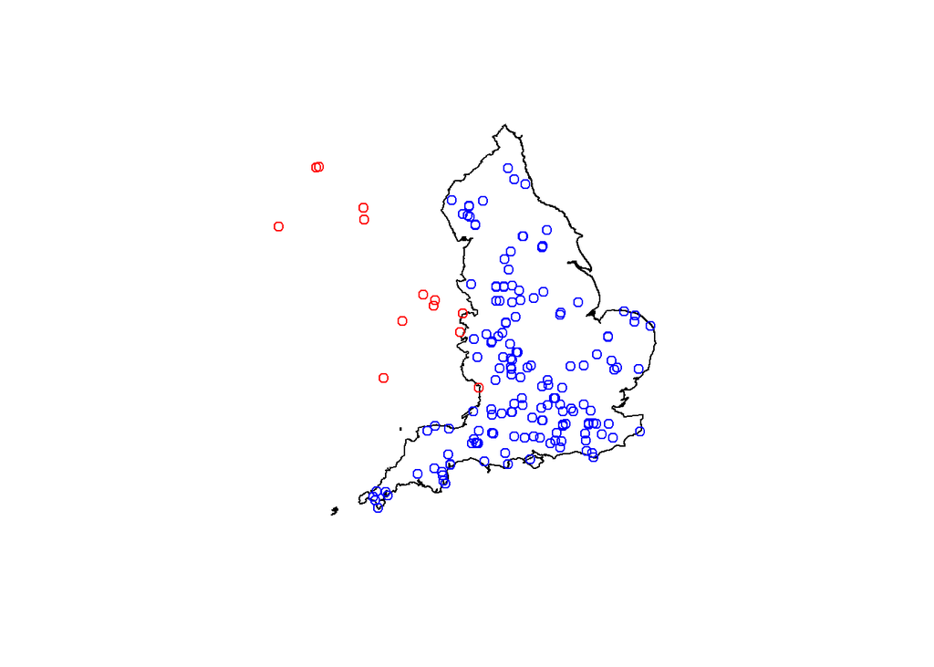

```r
nt_houses_c <- gCentroid(nt_houses, byid = TRUE)

nt_houses_c <- SpatialPointsDataFrame(nt_houses_c, as.data.frame(nt_houses$Name))

nt_houses_c <- spTransform(nt_houses_c, "+proj=longlat +ellps=WGS84 +datum=WGS84 +no_defs")

nt_houses_c_eng <- nt_houses_c[!is.na(over(nt_houses_c, eng_outline)),]

plot(eng_outline)
points(nt_houses_c, col = "red")
points(nt_houses_c_eng, col = "blue")
```

```r
isolist <- list()

for (i in 1:length(nt_houses_c_eng)){
  while(TRUE){
    iso <- try(osrmIsochrone(loc = nt_houses_c_eng[i,], breaks = seq(from = 0,to = 60, by = 60)))
    if(!is(iso, 'try-error')) break
  }
  isolist[[i]] <- iso
}

isos <- do.call(bind, isolist)

drivetime_extent <- unionSpatialPolygons(isos, ID = isos$id)
```

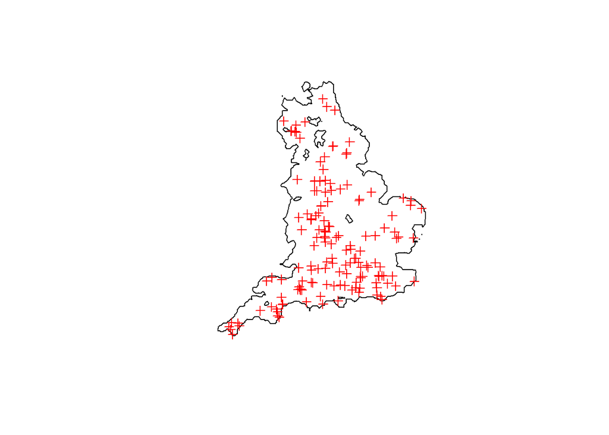

```r
plot(drivetime_extent)
plot(nt_houses_c_eng, add = T, col = "red")
```

# Accessibility Analysis

```r
oa <- merge(oa, pop, by.x = "code", by.y = "GeographyCode")

oa_c <- gCentroid(oa, byid = TRUE)

oa_c <- SpatialPointsDataFrame(oa_c, as.data.frame(oa))

oa_c <- spTransform(oa_c, "+proj=longlat +ellps=WGS84 +datum=WGS84 +no_defs")
```

```r
oa_c_60 <- !is.na(over(oa_c, drivetime_extent))

# Percentage of Population that are further than 60 minutes drive time from a National Trust house.
sum(oa_c[!oa_c_60, ]$QS102EW0001) / sum(oa_c$QS102EW0001) * 100
```

```
## [1] 1.679105
```

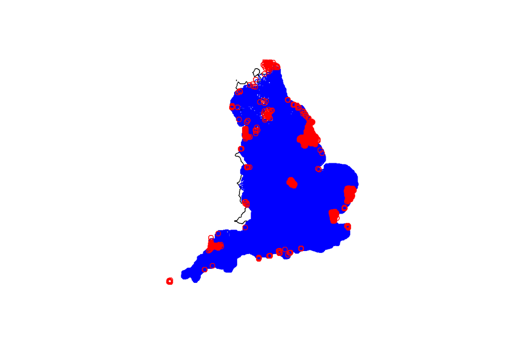

```r
plot(drivetime_extent)
#Output Area centroid inside 60 minute drive time from National Trust house.
points(oa_c[oa_c_60, ], pch=1, col="blue")
#Output Area centroid not inside 60 minute drive time from National Trust house.
points(oa_c[!oa_c_60, ], pch=1, col="red")
```

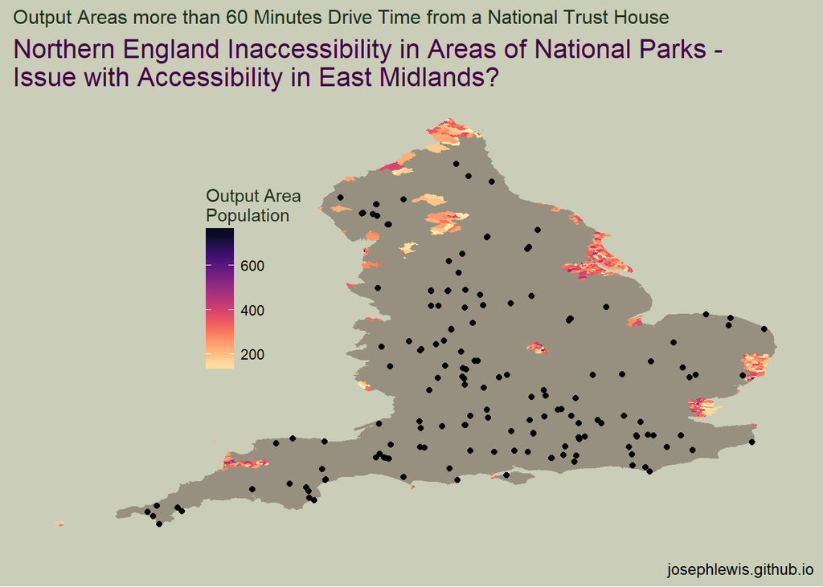

```r
oa_c$access[oa_c_60] <-"Output Area Accessible within 60 Minutes Drive Time"
oa_c$access[!oa_c_60] <-"Output Area Not Accessible within 60 Minutes Drive Time"

noaccess60 <- oa[!oa_c_60,]

noaccess60 <- fortify(noaccess60, region = "code")

noaccess60 <- merge(noaccess60, pop, by.x = "id", by.y = "GeographyCode")

eng_outline <- spTransform(eng_outline, crs(oa))

eng_outline <- fortify(eng_outline)

nt_houses_c_eng <- spTransform(nt_houses_c_eng, crs(oa))

nt_houses_c_eng <- as.data.frame(nt_houses_c_eng)

ggplot() +
  geom_polygon(data = eng_outline, aes(x = long, y = lat, group = group), fill = "#979080") +
  geom_polygon(data = noaccess60, aes(x = long, y = lat, group = group, fill = QS102EW0001)) +
  geom_point(data = nt_houses_c_eng, aes(x = x, y = y)) +
  scale_fill_viridis(option = "magma", direction = -1) +
  theme_classic() +
  theme(
    axis.line = element_blank(),
    axis.text.x = element_blank(),
    axis.text.y = element_blank(),
    axis.ticks = element_blank(),
    axis.title.x = element_blank(),
    axis.title.y = element_blank(),
    plot.background = element_rect(fill = "#CACDB8", color = NA),
    panel.background = element_rect(fill = "#CACDB8", color = NA),
    legend.background=element_blank(),
    panel.border = element_blank(),
    plot.subtitle = element_text(size = 16, colour = "#420147"),
    plot.title = element_text(size = 12, colour = "#1E311E"),
    legend.title = element_text(colour = "#1E311E"),
    legend.position = c(0.3, 0.6)) +
  labs(fill = "Output Area\nPopulation", title = "Output Areas more than 60 Minutes Drive Time from a National Trust House", subtitle = "Northern England Inaccessibility in Areas of National Parks -\nIssue with Accessibility in East Midlands?", caption = "josephlewis.github.io")
```

# Future Developments

- Scrape National Trust house locations from National Trust website and geocode, instead of using Open Street Map.
- Create an ‘opportunity score’ by getting the ratio of population density to National Trust houses for each output area centroid. This will allow for comparison amongst output areas.
- The Cumulative opportunity method assumes that only National Trust houses within 60 minutes drive time are accessible; the method does not consider that the drive time may vary depending on the National Trust house. Therefore, other accessibility measures should be explored, such as Utility Based measures (Handy and Niemeier, 1997).

# References

Golub, A. Martens, K (2014). “Using principles of justice to assess the modal equity of regional transportation plans”. Journal of Transport Geography, 41, 10-20.

Guers, K.T. van Eck, J.R.R (2001). “Accessibility Measures: Review and Applications: Evaluation of Accessibility Impacts of Land-use Transport Scenarios, and Related Social and Economic Impacts.” National Institute of Public Health and the Environment, The Netherlands.

Guers, K.T. van Wee, B (2004). “Accessibility Evaluation of Land-use and Transport Strategies: Review and Research Directions”. Journal of Transport Geography, 12, 127-140.

Guers, Karst T., and Bert van Wee. 2004. “Accessibility Evaluation of Land-use and Transport Strategies: Review and Research Directions.” Journal of Transport Geography 12: 127–40.

Handy, S.L. Niemeir, D.A (1997). “Measuring accessibility: an exploration of issues and alternatives”. Environment and planning A, 29, 1175-1194.

National Trust (2014). Playing our part: What does the nation need from the National Trust in the 21st century? Available at:https://www.nationaltrust.org.uk/documents/national-trust-playing-our-part.pdf [Accessed 23 June 2018].

Talen, E (2003). “Neighbourhoods as service providers: A methodology for evaluating pedestrian access,” Environment and Planning B: Planning and Design, 30, 181–200.

Vickerman, R (1974). “Accessibility attraction and potential: A review of some concepts and their use in determining mobility”. Environment and Planning A, 6, 675-691.